# R Intermediate Course 2026

Inferential Statistics

Bioinformatics Core Facility CECAD

2026-09-11

## Slides & Code

- *[f]* Full screen
- *[o]* Slide Overview
- *[c]* Notes
- *[h]* help

### git repo

[R-Basic](https://github.com/CECADBioinformaticsCoreFacility/Intermediate_R_Course_2025)

### Clone repo

`git clone https://github.com/CECADBioinformaticsCoreFacility/Intermediate_R_Course_2026.git`

### Slides Directly

https://cecadbioinformaticscorefacility.github.io/Intermediate_R_Course_2026/

**Session 4 :: Inferential Statistics**

```
.
├── Descriptive Statistics
│
│
│
```

```
└── Inferential Statistics
```

**Session 4 :: Inferential Statistics**

```
.
├── Descriptive Statistics
|    └── Describes an individual dataset by e.g.
|        ├── Central Tendency (Mean, Median, Mode)
|        ├── Measures of Variability (Range, Variance, Standard Deviation)
|        └── Frequency distribution
```

```
└── Inferential Statistics
```

**Session 4 :: Inferential Statistics**

```
.
├── Descriptive Statistics
|    └── Describes an individual dataset by e.g.
|        ├── Central Tendency (Mean, Median, Mode)
|        ├── Measures of Variability (Range, Variance, Standard Deviation)
|        └── Frequency distribution
```

```
└── Inferential Statistics
     └── Uses a small sample to make predictions about an entire population
         ├── Hypothesis testing ( --> p-value)
         └── Confidence intervals for inferred values of numerical parameters
```

## Categorical Tests

[figure not shown]

## The Chi-Square[d] Test – Idea

- Given
  - a set of individuals (anything: mice, days of the year, soil samples …)
  - one or more categorical trait(s), measured on each individual  
    (symptom severity, ice day or not, whether species X was found in a soil sample …)
  - a pre-specified hypothesis about the frequencies of the categories
- The **test** rejects our hypothesis if **this chi-square distributed quantity** it “too large”:

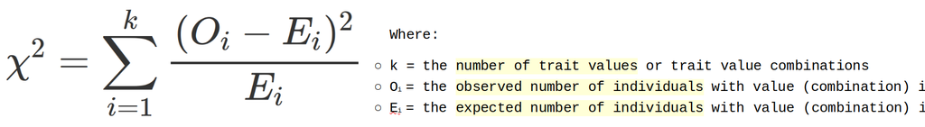

## Chi-Square Test of Goodness of Fit

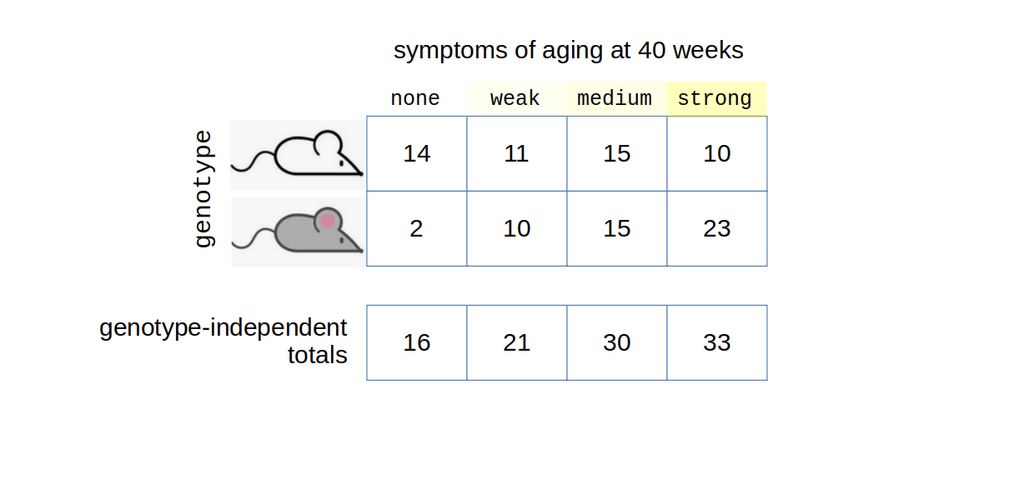

## Chi-Square Test of Goodness of Fit

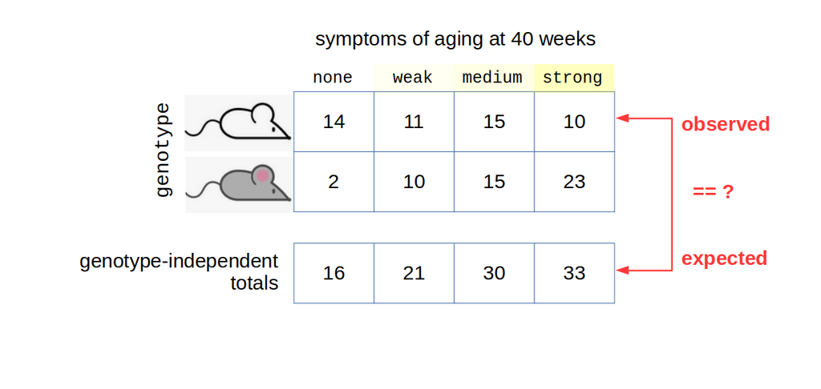

## Chi-Square Test of Goodness of Fit

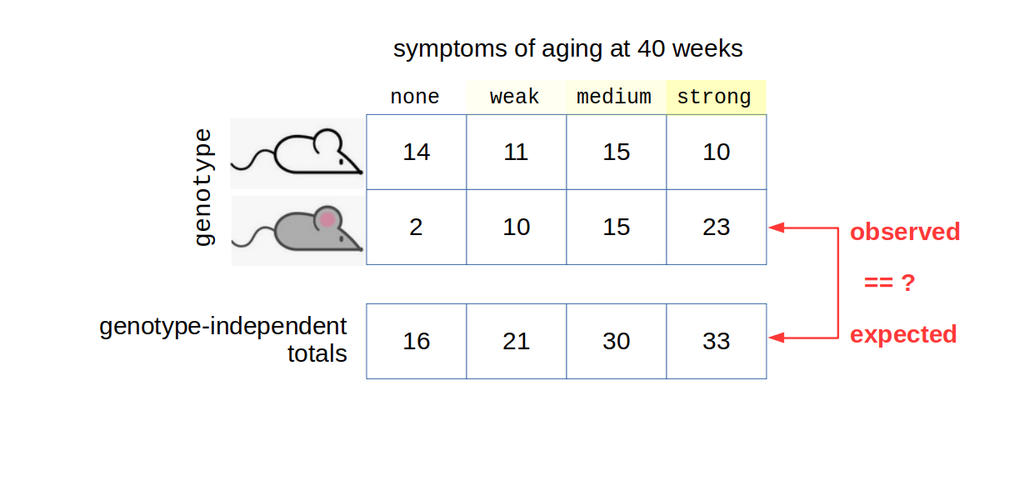

## Chi-Square Test of Goodness of Fit

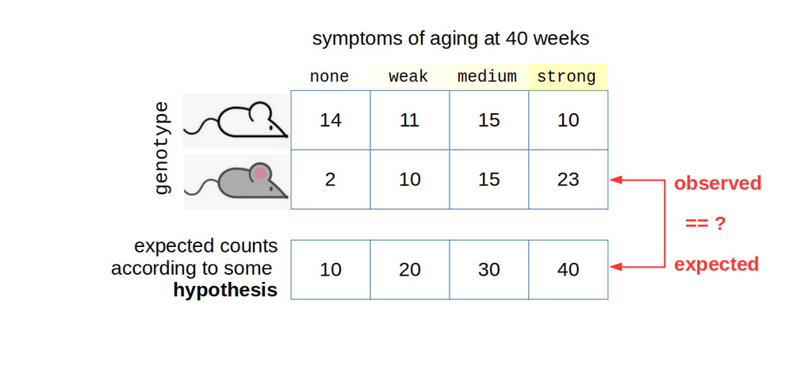

## Chi-Square Test of Independence [or: of Association]

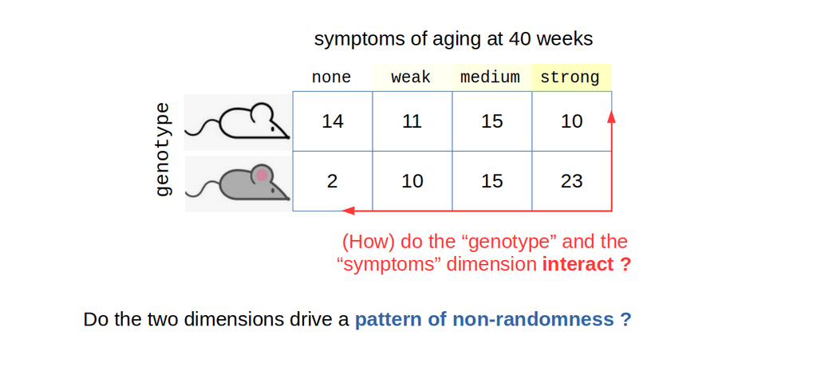

## Chi-Square Test of Independence – Expected Counts

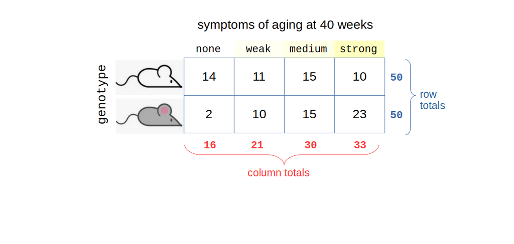

## Chi-Square Test of Independence – Expected Counts

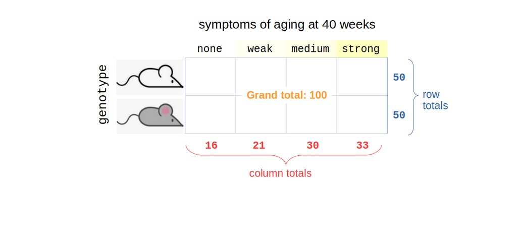

## Chi-Square Test of Independence – Expected Counts

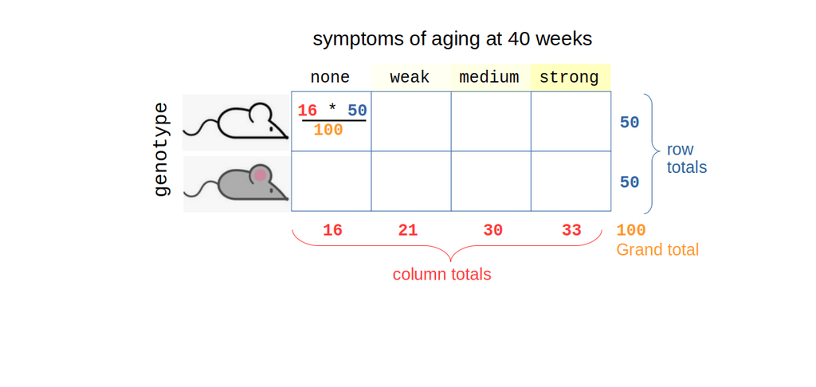

## Chi-Square Test of Independence – Expected Counts

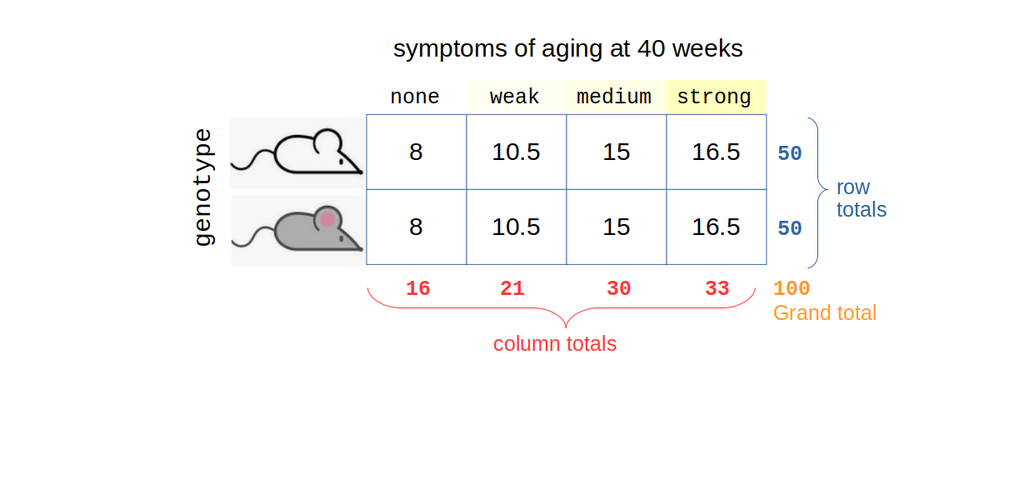

## Chi-Square Test of Independence – Expected Counts

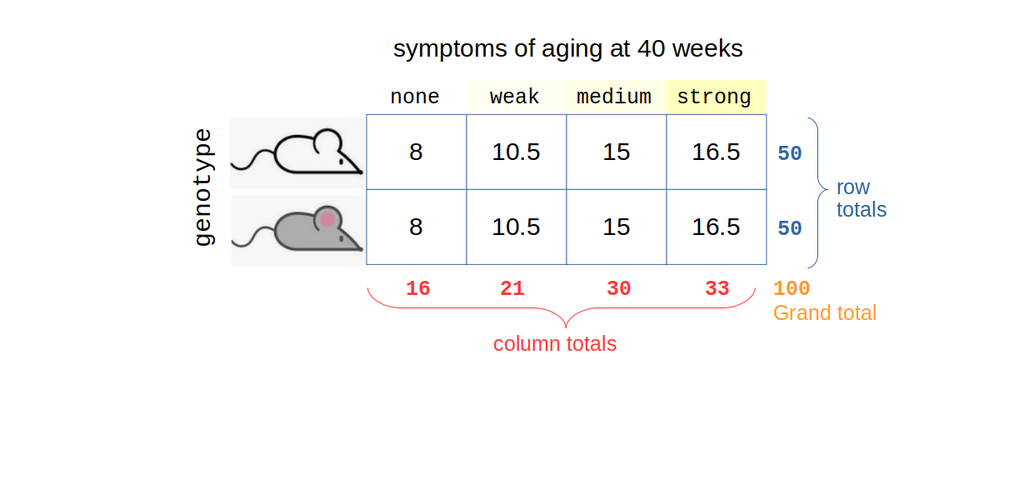

**Important**

For a chi-square test to be valid, **ideally all expected counts**, but **minimally 80% of the expected counts**, should be **>= 5** !

## Example Dataset

The data matrix used in the example is in the repository in the `data/` folder. Copy it to your project directory and read it into R like so:

```r
mouse_data <- readRDS("mouse_data.rds")

# Have look:
mouse_data
```

```
    genotype severity
1      white     none
2      white   strong
3      white   strong
4      white   strong
5      white   medium
6      white     none
7      white   strong
8      white     none
9      white   medium
10     white   strong
11     white   medium
12     white     weak
13     white     none
14     white   medium
```

[output cut: 86 more lines]

## Example Dataset

```r
genotype_frequencies <- table(mouse_data[,1])
genotype_frequencies
```

```
white black
   50    50
```

```r
symptom_frequencies <- table(mouse_data[,2])
symptom_frequencies
```

```
  none   weak medium strong
    16     21     30     33
```

A crossed table like this is called a contingency table:

```r
genotype_symptoms_crossed <-
  table(mouse_data[,1],mouse_data[,2])

genotype_symptoms_crossed
```

```
        none weak medium strong
  white   14   11     15     10
  black    2   10     15     23
```

```r
# If produced directly from the dataframe,
# the variable names appear in the output:
table(mouse_data)
```

```
        severity
genotype none weak medium strong
   white   14   11     15     10
   black    2   10     15     23
```

## Chi-square Tests in R – the **`chisq.test()`** Function

R’s main workhorse for doing chi square tests is **chisq.test** (in the base R package **stats**).

It shares a property of many base R functions:  
**it squeezes a lot of functionality into a single function**!

As for any built-in or loaded function, we can get a detailed documentation by:

## ?chisq.test

[interactive chart not shown]

## Chi-square Tests in R – the `chisq.test` Function

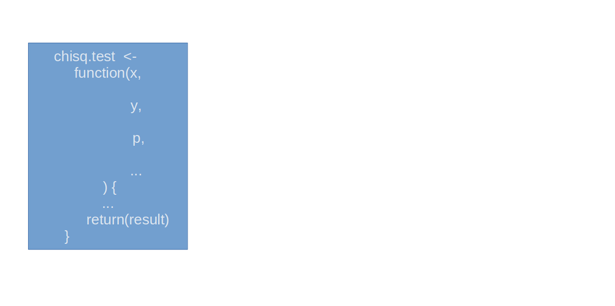

## Chi-square Tests in R – the `chisq.test` Function

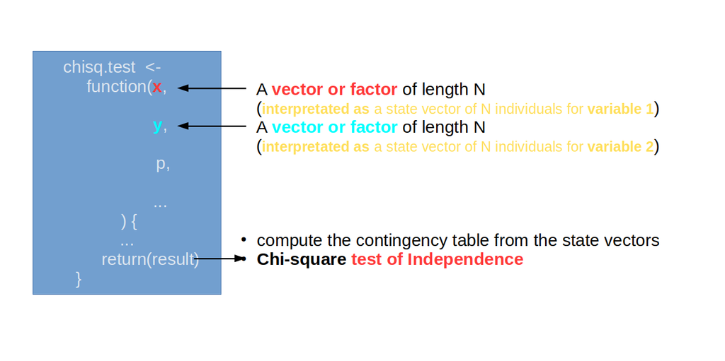

```r
chisq.test(x = mouse_data[,1],
           y = mouse_data[,2])
```

```
    Pearson's Chi-squared test

data:  mouse_data[, 1] and mouse_data[, 2]
X-squared = 14.169, df = 3, p-value = 0.002684
```

## Chi-square Tests in R – the `chisq.test` Function

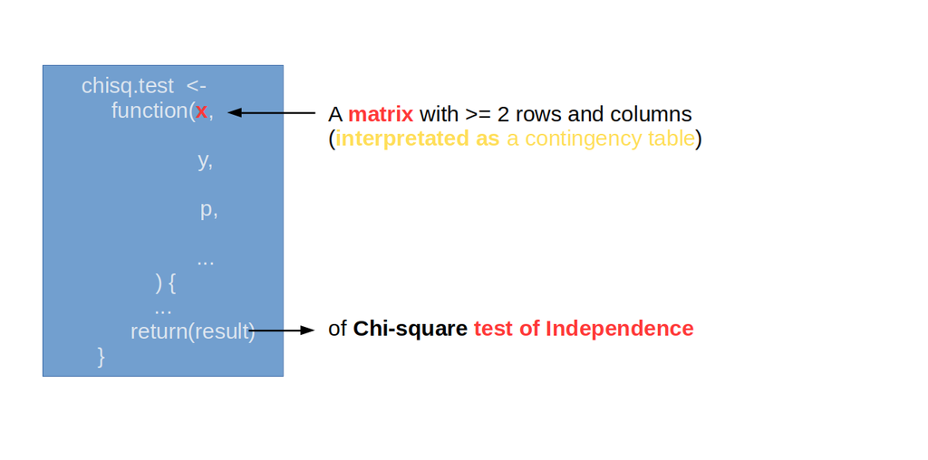

```r
chisq.test(x = table(mouse_data))
```

```
    Pearson's Chi-squared test

data:  table(mouse_data)
X-squared = 14.169, df = 3, p-value = 0.002684
```

## Chi-square Tests in R – the `chisq.test` Function

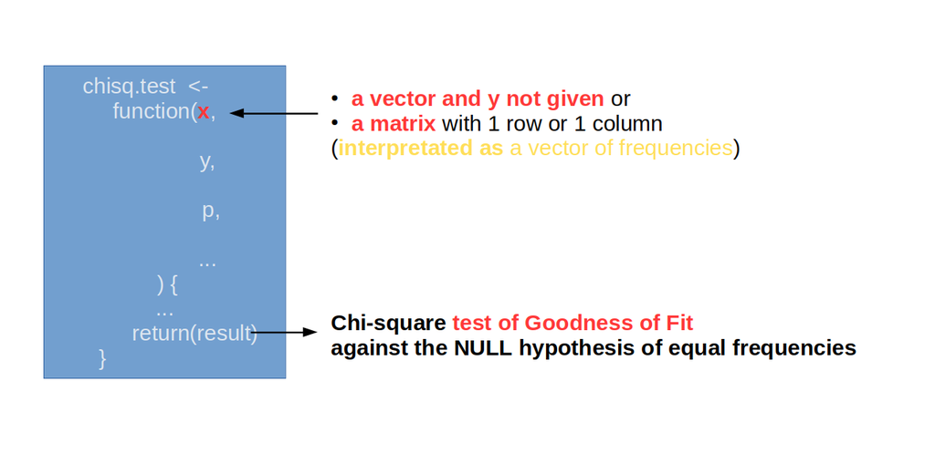

```r
# test the white genotype's frequencies
# against the uniform distribution
chisq.test(x = table(mouse_data)[1,])
```

```
    Chi-squared test for given probabilities

data:  table(mouse_data)[1, ]
X-squared = 1.36, df = 3, p-value = 0.7149
```

## Chi-square Tests in R – the `chisq.test` Function

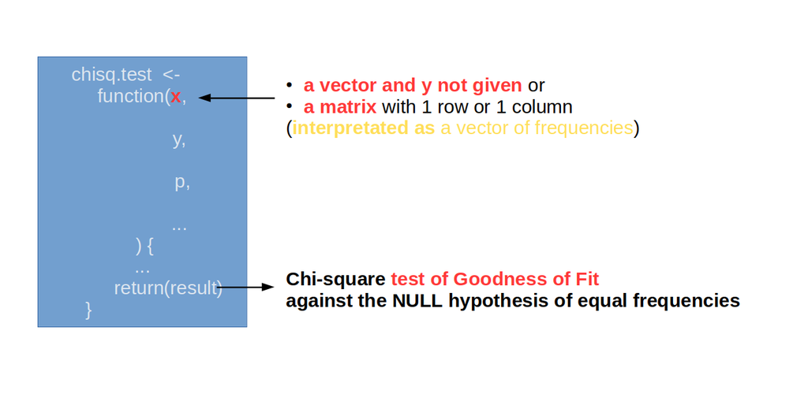

```r
# test the black genotype's frequencies
# against the uniform distribution
chisq.test(x = table(mouse_data)[2,])
```

```
    Chi-squared test for given probabilities

data:  table(mouse_data)[2, ]
X-squared = 18.64, df = 3, p-value = 0.0003245
```

## Chi-square Tests in R – the `chisq.test` Function

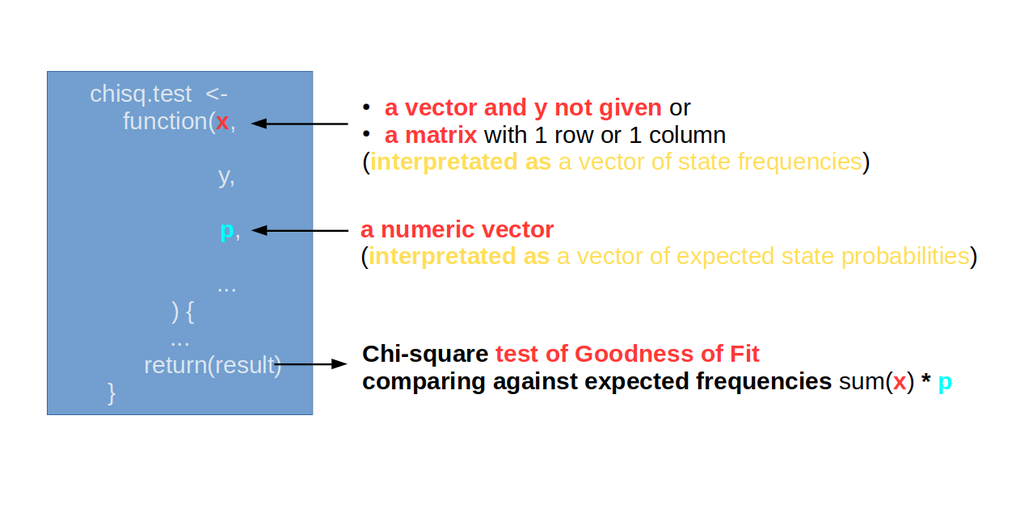

```r
# Are the black genotype's frequencies
# compatible with the white's probabilities?
tbl <- table(mouse_data)
chisq.test(x = tbl[2,], p = tbl[1,]/sum(tbl[1,]))
```

```
    Chi-squared test for given probabilities

data:  tbl[2, ]
X-squared = 27.277, df = 3, p-value = 5.151e-06
```

## An alternative For Sparse Tables – Fisher’s Exact Test

- For 2x2 contingency tables, it is possible to exactly calculate the total probability P of all tables with
  - the same row and column sums as the observed table
  - the same or a stronger non-uniform count distribution as the observed table
- This p-value calculation is not affected by small cell counts}
- For tables larger than 2x2, an extension exists which can still compute an exact p-value
- Function **`fisher.test`** implements both the 2x2 and the extended case

## ?fisher.test

[interactive chart not shown]

## An alternative For Sparse Tables – Fisher’s Exact Test

```r
fisher.test(x=mouse_data[,1], y=mouse_data[,2])
```

```
    Fisher's Exact Test for Count Data

data:  mouse_data[, 1] and mouse_data[, 2]
p-value = 0.002082
alternative hypothesis: two.sided
```

```r
# As with chisq.test, one can get the same result
# by specifying the pre-computed contingency table:
fisher.test(x=table(mouse_data))
```

```
    Fisher's Exact Test for Count Data

data:  table(mouse_data)
p-value = 0.002082
alternative hypothesis: two.sided
```

## Quantitative Tests (Numerical Data)

- Entry point: Our mouse **categorical data** and the **Normal Distribution**

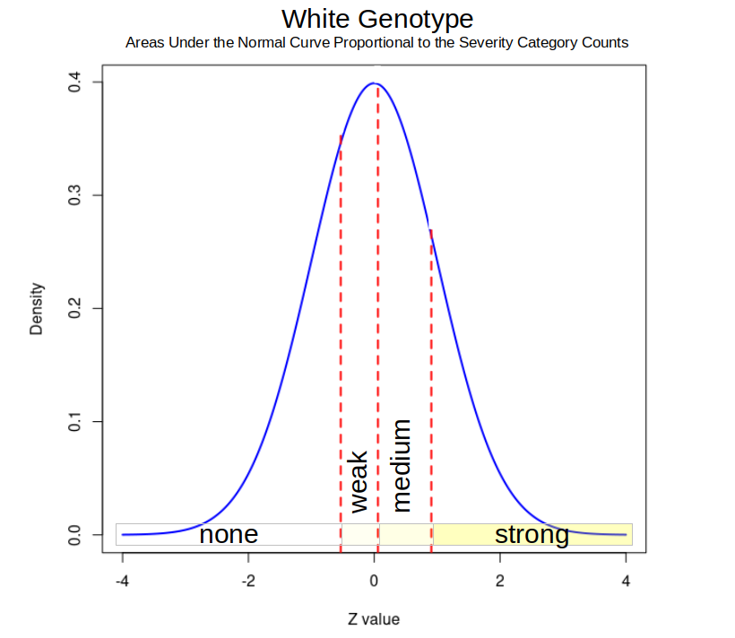

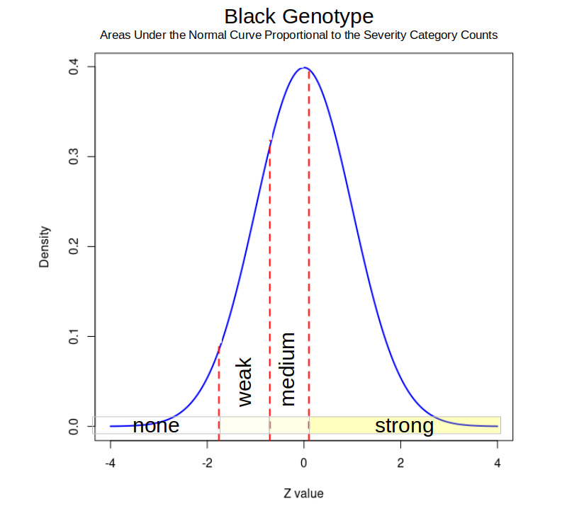

## Quantitative Tests (Numerical Data)

- A similar principle applies when numerical data are compared to a reference distribution:

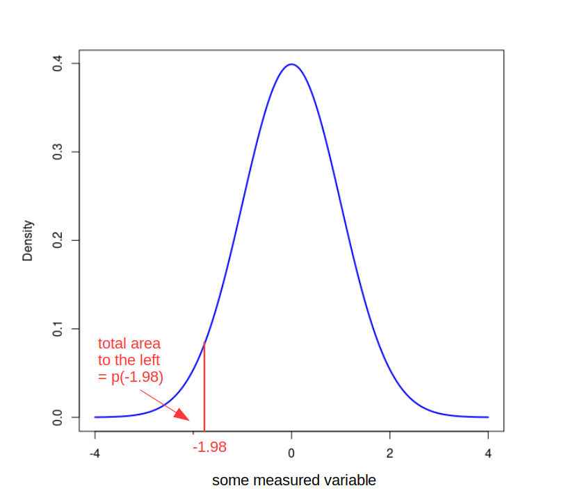

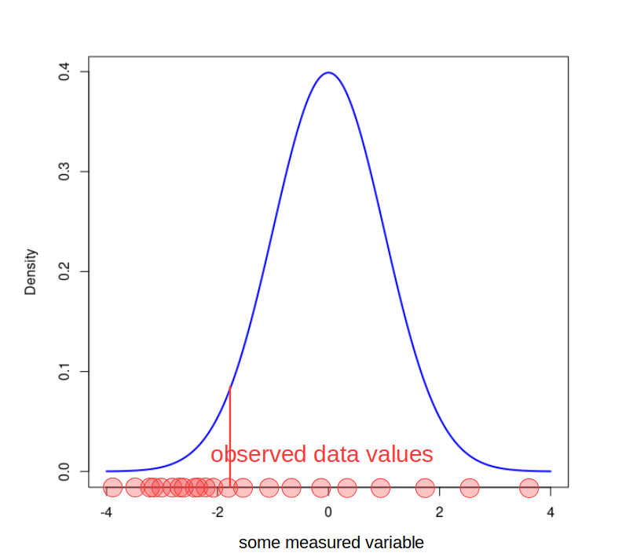

## Quantitative Tests (Numerical Data)

From here on we will use **`Fisher's Iris dataset`** as a (numerical) example.

```r
data(iris)
head(iris)
```

```
  Sepal.Length Sepal.Width Petal.Length Petal.Width Species
1          5.1         3.5          1.4         0.2  setosa
2          4.9         3.0          1.4         0.2  setosa
3          4.7         3.2          1.3         0.2  setosa
4          4.6         3.1          1.5         0.2  setosa
5          5.0         3.6          1.4         0.2  setosa
6          5.4         3.9          1.7         0.4  setosa
```

```r
summary(iris)
```

```
  Sepal.Length    Sepal.Width     Petal.Length    Petal.Width          Species
 Min.   :4.300   Min.   :2.000   Min.   :1.000   Min.   :0.100   setosa    :50
 1st Qu.:5.100   1st Qu.:2.800   1st Qu.:1.600   1st Qu.:0.300   versicolor:50
 Median :5.800   Median :3.000   Median :4.350   Median :1.300   virginica :50
 Mean   :5.843   Mean   :3.057   Mean   :3.758   Mean   :1.199
 3rd Qu.:6.400   3rd Qu.:3.300   3rd Qu.:5.100   3rd Qu.:1.800
 Max.   :7.900   Max.   :4.400   Max.   :6.900   Max.   :2.500
```

## Quantitative Tests (Numerical Data)

We will restrict ourselves here to the classical tests:

- t-test
- Anova
- linear model

These tests are conceptually closely related and build upon each other hierarchically.

## Test Functions and Their Assumptions

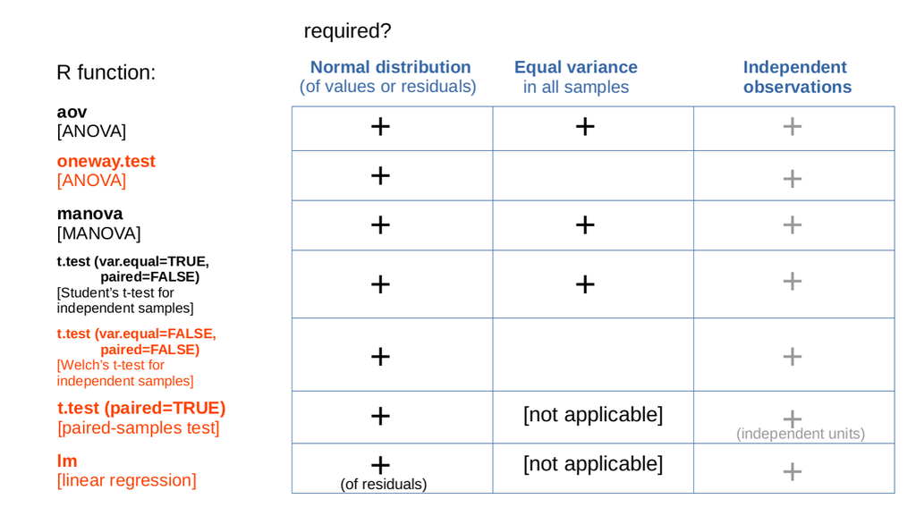

## Do the Assumptions Hold for the Iris Flower Traits?

#### Test Normality of Sepal.Length using shapiro.test():

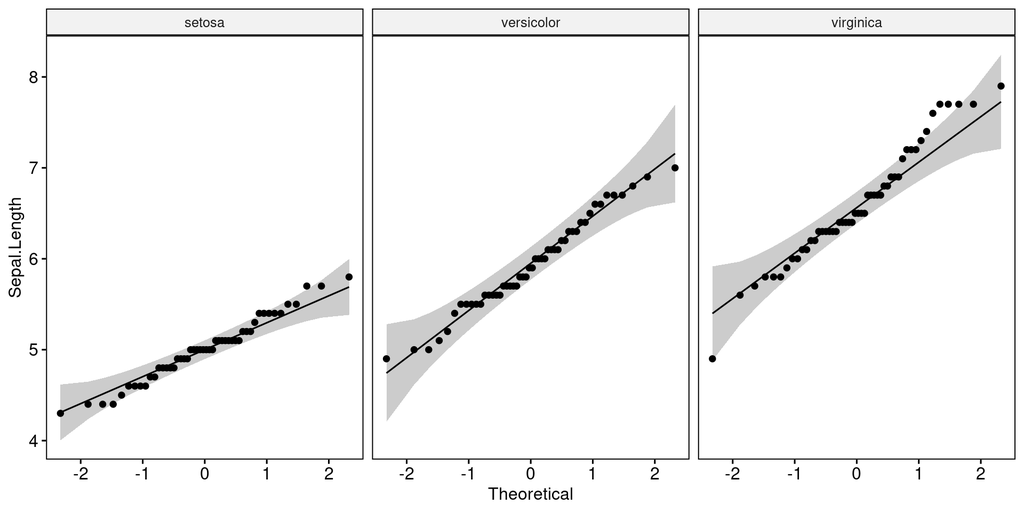

```r
use_trait <- "Sepal.Length"
ggpubr::ggqqplot(iris,
                 use_trait,
                 facet.by="Species",
                 ylab = use_trait
                )
```

```r
# This function  is defined in R/functions.R
run_test_on_groups(iris,
                  "Species",
                  use_trait,
                  shapiro.test)
```

```
     Species statistic   p.value                      method     test_var
1     setosa 0.9776985 0.4595132 Shapiro-Wilk normality test Sepal.Length
2 versicolor 0.9778357 0.4647370 Shapiro-Wilk normality test Sepal.Length
3  virginica 0.9711794 0.2583147 Shapiro-Wilk normality test Sepal.Length
```

## Do the Assumptions Hold for the Iris Flower Traits?

#### Test Normality of Sepal.Width using shapiro.test():

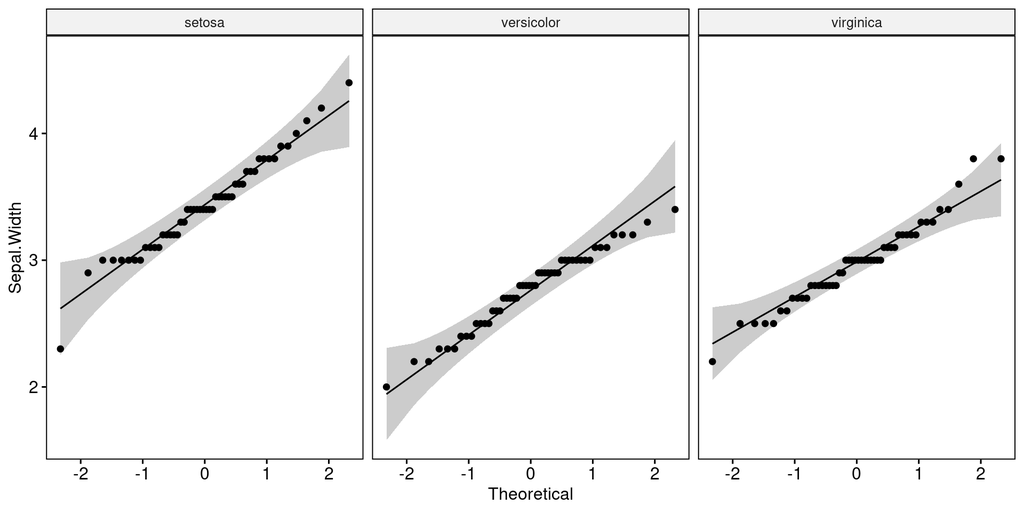

```r
use_trait <- "Sepal.Width"
ggpubr::ggqqplot(iris,
                 use_trait,
                 facet.by="Species",
                 ylab = use_trait
                )
```

```r
# This function  is defined in R/functions.R
run_test_on_groups(iris,
                  "Species",
                  use_trait,
                  shapiro.test)
```

```
     Species statistic   p.value                      method    test_var
1     setosa 0.9717195 0.2715264 Shapiro-Wilk normality test Sepal.Width
2 versicolor 0.9741333 0.3379951 Shapiro-Wilk normality test Sepal.Width
3  virginica 0.9673905 0.1808960 Shapiro-Wilk normality test Sepal.Width
```

## Do the Assumptions Hold for the Iris Flower Traits?

#### Test Normality of Petal.Length using shapiro.test():

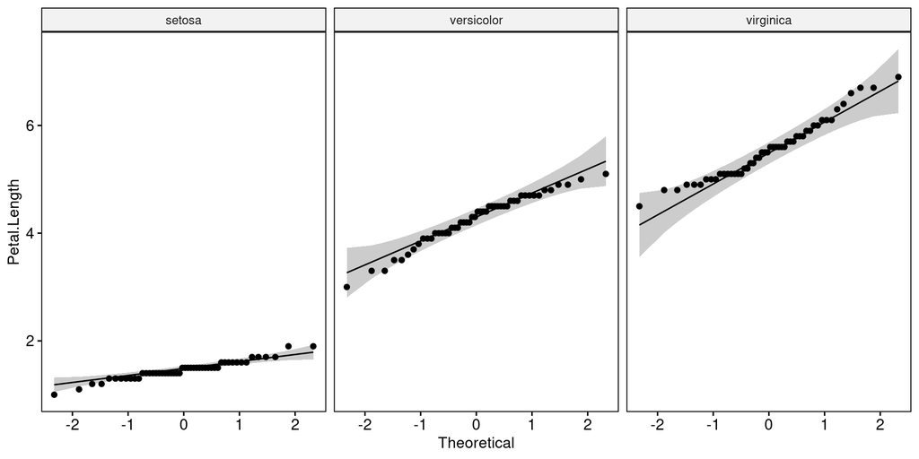

```r
use_trait <- "Petal.Length"
ggpubr::ggqqplot(iris,
                 use_trait,
                 facet.by="Species",
                 ylab = use_trait
                )
```

```r
# This function  is defined in R/functions.R
run_test_on_groups(iris,
                  "Species",
                  use_trait,
                  shapiro.test)
```

```
     Species statistic    p.value                      method     test_var
1     setosa 0.9549768 0.05481147 Shapiro-Wilk normality test Petal.Length
2 versicolor 0.9660044 0.15847784 Shapiro-Wilk normality test Petal.Length
3  virginica 0.9621864 0.10977537 Shapiro-Wilk normality test Petal.Length
```

## Do the Assumptions Hold for the Iris Flower Traits?

#### Test Normality of Petal.Width using shapiro.test():

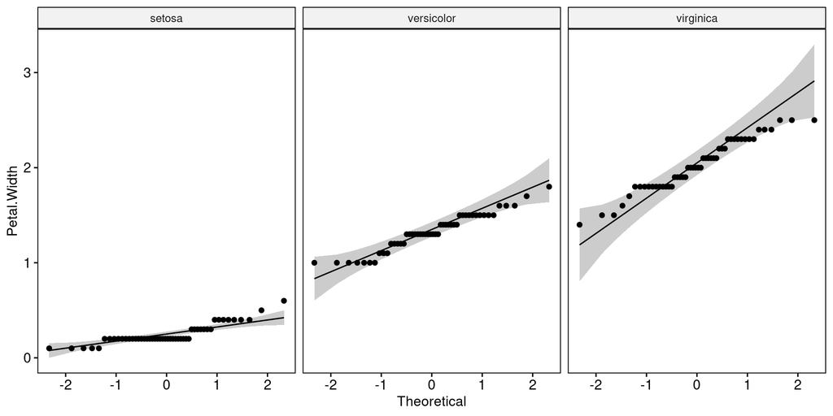

```r
use_trait <- "Petal.Width"
ggpubr::ggqqplot(iris,
                 use_trait,
                 facet.by="Species",
                 ylab = use_trait
                )
```

```r
# This function  is defined in R/functions.R
run_test_on_groups(iris,
                  "Species",
                  use_trait,
                  shapiro.test)
```

```
     Species statistic      p.value                      method    test_var
1     setosa 0.7997645 8.658573e-07 Shapiro-Wilk normality test Petal.Width
2 versicolor 0.9476263 2.727780e-02 Shapiro-Wilk normality test Petal.Width
3  virginica 0.9597715 8.695419e-02 Shapiro-Wilk normality test Petal.Width
```

## Do the Assumptions Hold for the Iris Flower Traits?

Regarding Normality:

- For the Sepals: **Yes!**
- For the Petals: **Marginally** to **No!**

## Do the Assumptions Hold For the Iris Flower Traits?

#### Test Equality of Variance of All Traits Using car::leveneTest:

```r
# run_levene() is defined in R/functions.R
purrr::map(colnames(iris)[-5],
           \(x) run_levene(iris,"Species",x)
) |> bind_rows()
```

```
# A tibble: 4 × 6
  statistic      p.value    df df.residual group_var test_var
      <dbl>        <dbl> <int>       <int> <chr>     <chr>
1     6.35  0.00226          2         147 Species   Sepal.Length
2     0.590 0.556            2         147 Species   Sepal.Width
3    19.5   0.0000000313     2         147 Species   Petal.Length
4    19.9   0.0000000226     2         147 Species   Petal.Width
```

## Do the Assumptions Hold For the Iris Flower Traits?

- There is **one conformer: Sepal.Width**
  - normally distributed in all species
  - “equal variance in all species” cannot be rejected
- A **marginal case: Sepal.Length**
  - normally distributed in all species
  - “equal variance in all species” is rejected, but with a less extreme p-value
- The **Petals tend to violate both assumptions**:
  - “normal distribution in all species” is borderline to clearly rejected
  - “equal variance in all species” is very clearly rejected

## A Quick Tour of Concepts: One-Sample T-Test

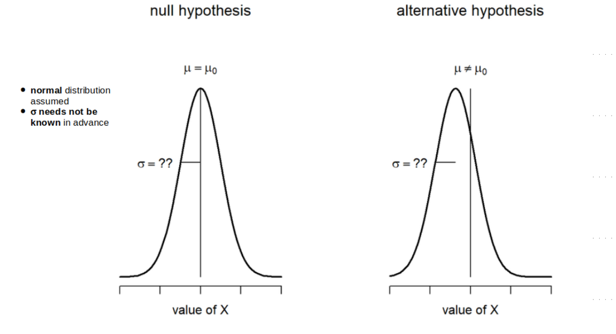

It tests whether an unknown population mean is different from a specific value.

## Remark on Danielle Navarro’s Lectures

Most of the **`Quick Tour of Concepts`** images are from here:  
Learning Statistics with R - A_tutorial for Psychology Students and other Beginners

## A Quick Tour of Concepts: Independent Samples T-Test

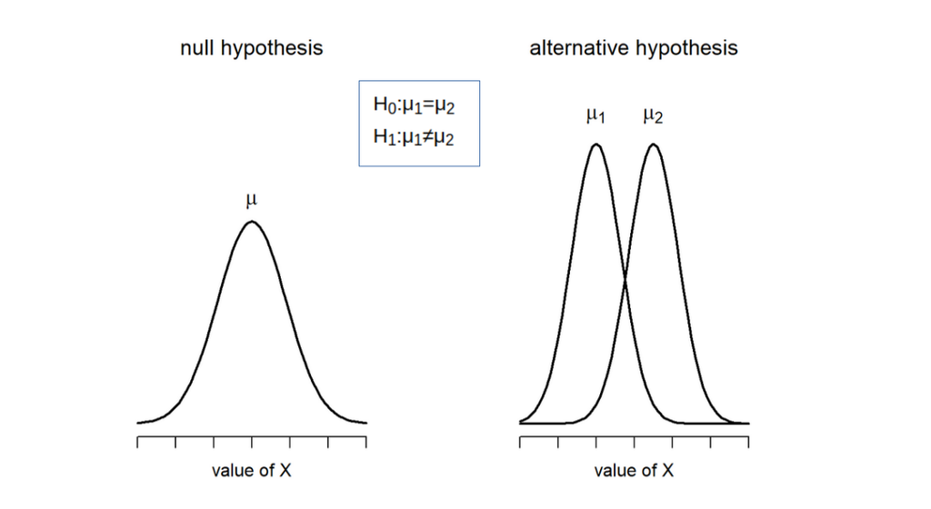

It tests whether two population means are identical.

## A Quick Tour of Concepts: Paired Samples T-Test

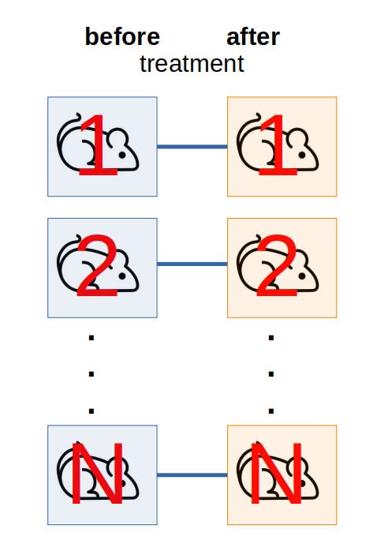

It tests whether the mean difference between pairs of measurements is zero or not.

## Running T-Tests in R – the **`t.test() function`**

The t.test() function is defined in the **stats** package like chisq.test(). It, too, is multi-functional, in the sense that it **can run all variants of t-tests described above**.

See its help page:

## ?t.test

[interactive chart not shown]

## Running T-Tests in R – the **`t.test() function`**

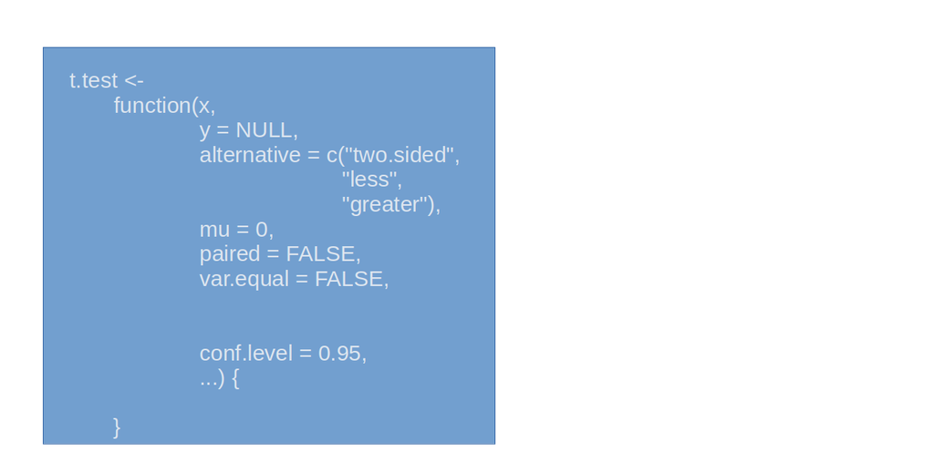